# Credit Card Segmentation Solution

## K-Means Clustering

Now, we will use K-Means clustering to group data based on their attribute. First, we need to determine the optimal number of groups. For that we conduct the knee test to see where the knee happens.

```python
#Finding optimal no. of clusters

cluster_range = range(1,15)
cluster_errors = []
for num_clusters in cluster_range:
    clusters = KMeans(num_clusters, n_init = 5)
    clusters.fit(df_z)
    labels = clusters.labels_
    centroids = clusters.cluster_centers_
    cluster_errors.append(clusters.inertia_)

clusters_df = pd.DataFrame({"num_clusters": cluster_range, "cluster_errors": cluster_errors})
clusters_df[0:15]
```

|  | num_clusters | cluster_errors |
| --- | --- | --- |
| 0 | 1 | 3275.000000 |
| 1 | 2 | 1907.511872 |
| 2 | 3 | 1087.282243 |
| 3 | 4 | 860.395889 |
| 4 | 5 | 776.074818 |
| 5 | 6 | 698.561418 |
| 6 | 7 | 635.611778 |
| 7 | 8 | 607.173303 |
| 8 | 9 | 585.261495 |
| 9 | 10 | 560.447053 |
| 10 | 11 | 536.730748 |
| 11 | 12 | 516.619468 |
| 12 | 13 | 502.843077 |
| 13 | 14 | 484.339356 |

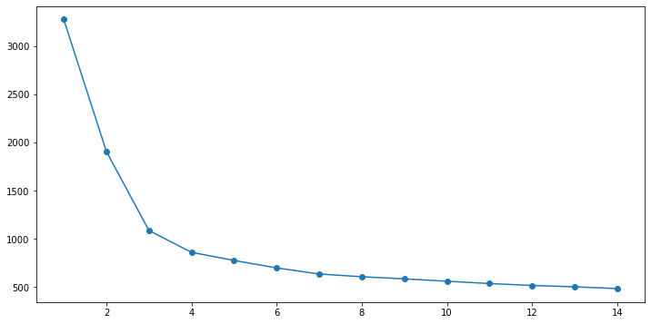

```python
from matplotlib import cm

plt.figure(figsize=(12,6))
plt.plot( clusters_df.num_clusters, clusters_df.cluster_errors, marker = "o" )
```

```python
# We could see the bend is getting less steep at 4, so we tested with 4 clusters, but its silhouette score got low, and two clusters out 4 were having no clear demarcation.
# No of cluster to 3 is giving much better segmentation of customers

kmeans = KMeans(n_clusters=3, n_init = 5, random_state=12345)
kmeans.fit(df_z)
```

```
KMeans(n_clusters=3, n_init=5, random_state=12345)
```

```python
# Check the number of data in each cluster

labels = kmeans.labels_
counts = np.bincount(labels[labels>=0])
print(counts)
```

```
[ 50 223 382]
```

```python
# let us check the centers in each group
centroids = kmeans.cluster_centers_
centroid_df = pd.DataFrame(centroids, columns = list(df_z) )
centroid_df.transpose()
```

|  | 0 | 1 | 2 |
| --- | --- | --- | --- |
| Avg_Credit_Limit | 1.964724 | -0.727993 | 0.167817 |
| Total_Credit_Cards | 1.862927 | -1.056442 | 0.372880 |
| Total_visits_bank | -1.102889 | -0.898670 | 0.668974 |
| Total_visits_online | 2.503449 | 0.529642 | -0.636865 |
| Total_calls_made | -0.878951 | 1.144417 | -0.553030 |

```python
# Add cluster number to original data
df_orig = df.copy()
predictions = kmeans.predict(df_z)
predictions
df_orig["group"] = predictions
df_orig['group'] = df_orig['group'].astype('category')
df_orig.dtypes
```

```
Sl_No                     int64
Customer Key              int64
Avg_Credit_Limit          int64
Total_Credit_Cards        int64
Total_visits_bank         int64
Total_visits_online       int64
Total_calls_made          int64
group                  category
dtype: object
```

```python
# Silhouette Score - KMeans
score = silhouette_score(df_z, predictions)
score
```

```
0.5030917192881229
```

```python
df_cluster = df_orig.groupby(['group'])
df_cluster.mean()
```

| group | Sl_No | Customer Key | Avg_Credit_Limit | Total_Credit_Cards | Total_visits_bank | Total_visits_online | Total_calls_made |
| --- | --- | --- | --- | --- | --- | --- | --- |
| 0 | 611.280000 | 56708.760000 | 141040.000000 | 8.740000 | 0.600000 | 10.900000 | 1.080000 |
| 1 | 117.914798 | 55048.372197 | 12152.466368 | 2.412556 | 0.932735 | 3.560538 | 6.856502 |
| 2 | 417.450262 | 54847.824607 | 33746.073298 | 5.510471 | 3.486911 | 0.981675 | 2.010471 |

```
array([[<matplotlib.axes._subplots.AxesSubplot object at 0x000001E4AA61E160>,
      dtype=object)
```

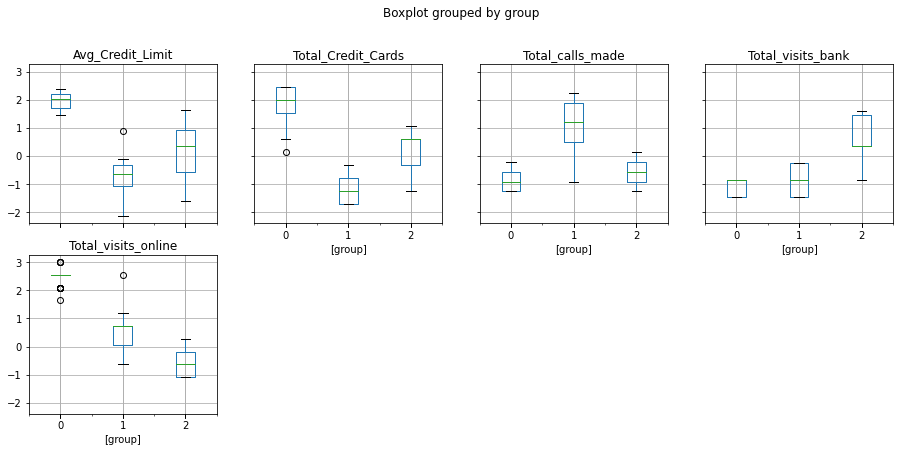

```python
# Visualize the centers
df_z_plot = df_z.copy()
df_z_plot["group"] = predictions
df_z_plot.boxplot(by = 'group',  layout=(3,4), figsize=(15, 10))
```

### K-Means Conclusion

Based on boxplot and groups

- Group 0 - Lowest no of clients, with highest avg_credit_limit, total_credit_cards, total_visits_online
- Group 1 - Lowest avg_credit_limit, total_credit_cards, with highest no of calls made to bank
- Group 2 - Compared other groups balanced avg_credit_limit, total credit cards,lowest online visits and little high total_visits_bank. Balanced customers.

## Hierarchical Clustering

```python
# We will calculate cophenet score and will analyze through Dendrograms, and will use Agglomerative CLustering here.
# cophenet index is a measure of the correlation between the distance of points in feature space and distance on dendrogram
# closer it is to 1, the better is the clustering

from sklearn.cluster import AgglomerativeClustering
```

### Linkages - Dendrograms

#### Linkage - Average

```python
#### generate the linkage matrix
from scipy.cluster.hierarchy import cophenet, dendrogram, linkage
from scipy.spatial.distance import pdist  #Pairwise distribution between data points

Z = linkage(df_z, metric='euclidean', method='average')
c, coph_dists = cophenet(Z , pdist(df_z))

c
```

```
0.8751104167922202
```

```python
Z[:]
```

```
array([[4.60000000e+02, 4.93000000e+02, 0.00000000e+00, 2.00000000e+00],
       [4.22000000e+02, 4.51000000e+02, 0.00000000e+00, 2.00000000e+00],
       [2.49000000e+02, 3.59000000e+02, 0.00000000e+00, 2.00000000e+00],
       ...,
       [1.00000000e+00, 1.30100000e+03, 2.97659131e+00, 2.23000000e+02],
       [1.30500000e+03, 1.30600000e+03, 3.51545966e+00, 6.05000000e+02],
       [1.30000000e+03, 1.30700000e+03, 4.73211910e+00, 6.55000000e+02]])
```

### Plot the dendrogram for the consolidated dataframe

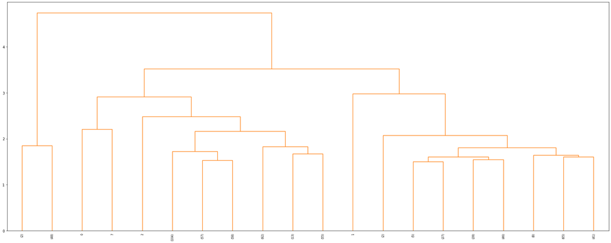

```python
plt.figure(figsize=(25, 10))
dendrogram(Z, leaf_rotation=90.,color_threshold = 40, leaf_font_size=8.,
           truncate_mode='lastp',  # show only the last p merged clusters
    p=20)  # show only the last p merged clusters
plt.tight_layout()
```

#### Linkage - Complete

```python
Z_Complete = linkage(df_z, metric='euclidean', method='complete')
c, coph_dists = cophenet(Z_Complete , pdist(df_z))

c
```

```
0.8305754803876207
```

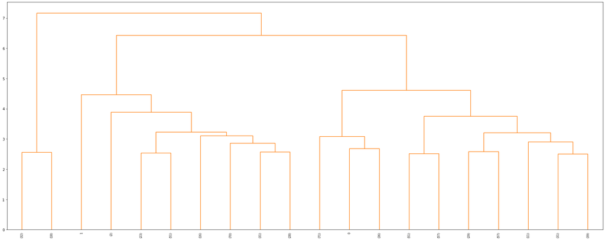

```python
plt.figure(figsize=(25, 10))
dendrogram(Z_Complete, leaf_rotation=90.,color_threshold = 40, leaf_font_size=8.,truncate_mode='lastp',p=20)
plt.tight_layout()
```

#### Linkage - Ward

```python
Z_Ward = linkage(df_z, metric='euclidean', method='ward')
c, coph_dists = cophenet(Z_Ward , pdist(df_z))

c
```

```
0.77319009891092
```

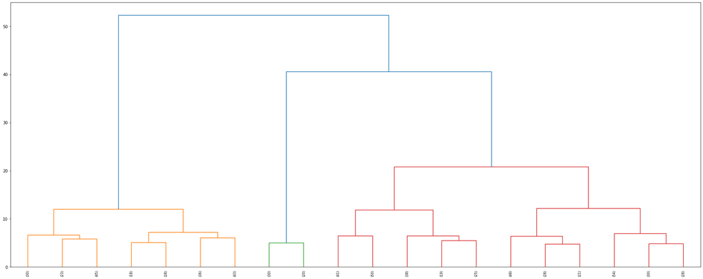

```python
plt.figure(figsize=(25, 10))
dendrogram(Z_Ward, leaf_rotation=90.,color_threshold = 40, leaf_font_size=8.,truncate_mode='lastp',p=20)
plt.tight_layout()
```

#### Linkage - Centroid

```python
Z_Centroid = linkage(df_z, metric='euclidean', method='centroid')
c, coph_dists = cophenet(Z_Centroid , pdist(df_z))

c
```

```
0.8717842240622813
```

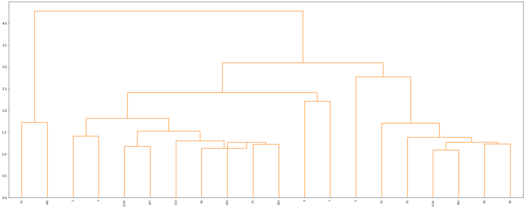

```python
plt.figure(figsize=(25, 10))
dendrogram(Z_Centroid, leaf_rotation=90.,color_threshold = 40, leaf_font_size=8.,truncate_mode='lastp',p=20)
plt.tight_layout()
```

### From the truncated dendrogram, find out the optimal distance between clusters which u want to use an input for clustering data

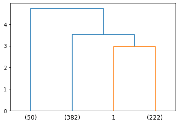

```python
# Use truncate_mode='lastp' attribute in dendrogram function to arrive at dendrogram
dendrogram(
    Z,
    truncate_mode='lastp',  # show only the last p merged clusters
    p=4,  # show only the last p merged clusters
)
plt.show()
```

```python
# From above Dendrogram created using 'Average' linkage ('Z'), which is giving best Cophenate score, we can see 3 groups are getting created.
# We are avoiding creating separate cluster for 1 data point.
```

### Use this distance measure(max_d) and fcluster function to cluster the data into 3 different groups

```python
from scipy.cluster.hierarchy import fcluster
max_d = 3
clusters = fcluster(Z, max_d, criterion='distance')
clusters
```

[output not shown]

```python
# Calculate Avg Silhoutte Score

silhouette_score(df_z,clusters)
```

```
0.5028378504692518
```

Silhouette Score is better when closer 1 and worse when closer to -1

- 0.5030917192881229 was for KMeans Clustering method

## Agglomerative Clustering - Model Fitting

Based on linkages generated above

```python
# From the above cophenet scoring of different linkages, we can go with 'average' linkage method.
model = AgglomerativeClustering(n_clusters=3, affinity='euclidean',  linkage='average')
model.fit(df_z)
df_h=df.copy()
df_h['labels'] = model.labels_
df_h.head(10)
```

|  | Sl_No | Customer Key | Avg_Credit_Limit | Total_Credit_Cards | Total_visits_bank | Total_visits_online | Total_calls_made | labels |
| --- | --- | --- | --- | --- | --- | --- | --- | --- |
| 0 | 1 | 87073 | 100000 | 2 | 1 | 1 | 0 | 2 |
| 1 | 2 | 38414 | 50000 | 3 | 0 | 10 | 9 | 0 |
| 2 | 3 | 17341 | 50000 | 7 | 1 | 3 | 4 | 2 |
| 3 | 4 | 40496 | 30000 | 5 | 1 | 1 | 4 | 2 |
| 4 | 5 | 47437 | 100000 | 6 | 0 | 12 | 3 | 1 |
| 5 | 6 | 58634 | 20000 | 3 | 0 | 1 | 8 | 0 |
| 6 | 7 | 48370 | 100000 | 5 | 0 | 11 | 2 | 1 |
| 7 | 8 | 37376 | 15000 | 3 | 0 | 1 | 1 | 2 |
| 8 | 9 | 82490 | 5000 | 2 | 0 | 2 | 2 | 0 |
| 9 | 10 | 44770 | 3000 | 4 | 0 | 1 | 7 | 0 |

```python
custCCClust = df_h.groupby(['labels'])
custCCClust.mean()
```

| labels | Sl_No | Customer Key | Avg_Credit_Limit | Total_Credit_Cards | Total_visits_bank | Total_visits_online | Total_calls_made |
| --- | --- | --- | --- | --- | --- | --- | --- |
| 0 | 119.174888 | 55101.982063 | 12116.591928 | 2.421525 | 0.941704 | 3.565022 | 6.869955 |
| 1 | 611.280000 | 56708.760000 | 141040.000000 | 8.740000 | 0.600000 | 10.900000 | 1.080000 |
| 2 | 416.714660 | 54816.528796 | 33767.015707 | 5.505236 | 3.481675 | 0.979058 | 2.002618 |

```
array([[<matplotlib.axes._subplots.AxesSubplot object at 0x000001E4AB966400>,
      dtype=object)
```

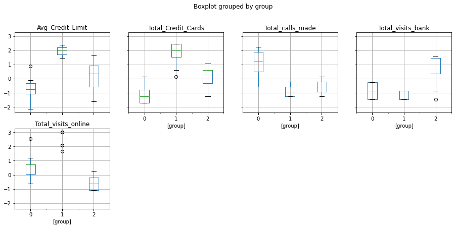

```python
# Visualize thorugh boxplot
df_zh_plot = df_z.copy()
df_zh_plot["group"] = model.labels_
df_zh_plot.boxplot(by = 'group',  layout=(3,4), figsize=(15, 10))
```

## Silhouette Scores - Hierarchical Vs K-Means

- K-Means --> 0.5030917192881229
- Hierarchical --> 0.5028378504692518

## Clusters Comparison - Hierarchical Vs K-Means

Clusters for both techniques are almost same. Both have 3 clusters each. Segmentation also showing same customer behaviour pattern in both.

Silhoutte score is little bit better for K-Means.

We can conclude that both clustering methods indicating same results.

## Key Questions

1.) How many different segments of customers are there?

- There are appeared to be 3 segments, based on existing data:
- Group 1 - 50 Customers - High Credit Limit, max no of cards, online visits maximum. Rarely make calls to bank and less visit to bank. No of customers are least in this group out of the 3 groups.
- Group 2 - 223 Customers - Lowest Credit limit/no of credit cards. Less frequent visit to bank/less online visits. Mostly contact via phone.
- Group 3 - 382 Customers - Average credit limit with comparatively high no of credit cards. Visit bank more frequently, and visit online rarely.

2.) How are these segments different from each other?

- Customers with high avg credit limit are more using online services and have higher no of credit cards compared to other segments.
- Customers with on an average less cards have lower credit limits. Mostly try to contact through phone.
- 3rd type of customers are balanced one and have good no of credit cards, average credit limit. Either visits bank or make calls to bank. Rarely visit online.

3.) What are your recommendations to the bank on how to better market to and service these customers? Based on pattern we can suggest following:

- Bank needs to improve online presence among group 2 and 3.
- Bank can offer more through branch to group-3, when customers visits branch.
- For group-1 customers, more digital ads can be targetted.